# Objetivo 2: Relación entre PISA STEM y Graduados en Carreras STEM

A continuación, explicaré el segundo objetivo que es el siguiente. Determinar si existe relación entre los países que obtienen mejores resultados en el informe PIPISA de 2015 y el porcentaje de graduados en STEM en 2022, partiendo de uqe los alumnos que realizaron la prueba son, por edad, los mismos que podrían habesre graduado 7 años después en 2022

# 1. DATOS Y FUENTES DE DATOS

- Base de datos PISA: con resultados académicos de niños de 15 años en distintos campos. Este conjunto de datos presenta las columnas País, Indicador, Sexo, Año del examen y puntuación obtenida. Esta base de datos ha sido sacada de la página web Kaggle y hecha por la Organización para la Cooperación y el Desarrollo Económico (OCDE)
- Base de datos STEM: contiene porcentajes de graduación en titulos universitarios en disciplinas científicas, técnologicas, de ingeniería y matemáticas por país y año. El valor de cada celda representa el porcentaje de personas graduadas en titulos universitarios en STEM ese año, sobre el total de titulados en el país. Esta base de datos ha sido extraída de EUROSTAT

#2. Transformaciones específicas

Para trabajar adeucadamente con los datos hemos realizado las siguientes transformaciones.

Para el conjunto de datos PISA realiza un filtrado para solo tener en cuenta los indicadores de Matemáticas y Ciencias de 2015 y para ambos sexos. Finalmente, agrupa los daos por país y calcula un promedio de las puntuaciones en matemáticas y , ignorando valores faltantes. Por tanto, quedará una tabala donde cada país aparece una sola vez, y tiene un único valor promedio.

Por otro lado, para la base de datos STEM pasamos de formato matriz a formato normal. Para despues eliminar las primeas 30 filas, que no contienen datos válidos y filtramos para quedarnos con solo datos del año 2022. Posteriormente, creamos una columna llamada iso3 con el código ISO3 de cada país, para poder cruzar la tabla con la de PISA y convertimos los valores de STEM_grad a números, por si vienen como texto. Por último, eliminamos las filas que tengan datos faltantes.

Una vez hemos transformado ambas bases de datos y están preparadas para tabajar sobre ellas, unimos estas quedandonos solo con los países que aparecen en los dos conjuntos.

```r
# PISA: Promedio de Ciencias y Matemáticas (2015)
pisa <- read_csv("C:/Users/tonif/Downloads/OECD PISA data.csv") %>%
  filter(TIME == 2015, INDICATOR %in% c("PISAMATH", "PISASCIENCE"), SUBJECT == "TOT") %>% # chicos y chicas
  group_by(iso3 = LOCATION) %>%
  summarise(PISA_STEM = mean(Value, na.rm = TRUE), .groups = "drop")

# Graduados en STEM: año 2022
stem <- read_excel("bachelorsSTEM.xlsx") %>%
  pivot_longer(cols = -TIME, names_to = "Year", values_to = "STEM_grad")   %>% # pasar de matriz a formato normal.
  slice(-(1:30)) %>%
  rename(Country = TIME) %>%
  filter(Year == "2022") %>%
  mutate(
    iso3 = countrycode(Country, "country.name", "iso3c"),
    STEM_grad = as.numeric(STEM_grad)
  ) %>%
  drop_na(iso3, STEM_grad)
```

#3. PLANTEAMIENTO DE LA SOLUCIÓN

Para la solución del objetivo se plantearán las siguientes técnicas. Al tratarse, por edad, de los mismos alumnos, se plantea un enfoque que combine análisis descripctivo y predictivo.

Primero estudiaremos el comportamiento general de las variables. Para ello, aplicaremos técnicas como la correlación y la regresión lineal

En segundo y último lugar, se aplica un modelo de Análisis Discriminenta Lineal con enfoque predictivo, para predecir si un país tendrá muchos o pocos graduados en STEM únicamente conociendo su puntuación PISA. Con ello, evaluaremos si la puntuación en PISA ayuda a diferenciar países según sus resultados en estudios posteriores.

```r
df <- inner_join(pisa, stem, by = "iso3")
```

# 4. DESAROLLO TÉCNICO

En primer, se comprobó que los datos no seguían una distribución normal, mediante el Test de Saphiro, ya que la variable PISA_STEM no sigue una distribución normal (p-valor> p-valorPISA_STEM). Todo ello, lleva a descartar el uso de la correlación de Pearson. Entonces, usaremos la correlación de Spearman, que no requiere normalidad

```r
shapiro_pisa <- shapiro.test(df$PISA_STEM)
shapiro_stem <- shapiro.test(df$STEM_grad)

cat("p-valor PISA_STEM:", round(shapiro_pisa$p.value, 5), "\n")
```

```
## p-valor PISA_STEM: 0.01694
```

```r
cat("p-valor STEM_grad:", round(shapiro_stem$p.value, 5), "\n")
```

```
## p-valor STEM_grad: 0.13483
```

La correlación de Spearman dio un valor positivo moderado (cor_spearman = 0.47), indicando que los países que obtienen mayores puntuaciones PISA tienden a tener más graduados en STEM

```r
cor_spearman <- cor.test(df$PISA_STEM, df$STEM_grad, method = "spearman")

cor_spearman
```

```
##
##  Spearman's rank correlation rho
##
## data:  df$PISA_STEM and df$STEM_grad
## S = 1375.3, p-value = 0.01747
## alternative hypothesis: true rho is not equal to 0
## sample estimates:
##       rho
## 0.4710411
```

A continuación, se aplicó un modelo de regresión para analizar si el rendimiento académico en PISA 2015 permite explicar o predecir el porcentaje de graduados en STEM en 2022.

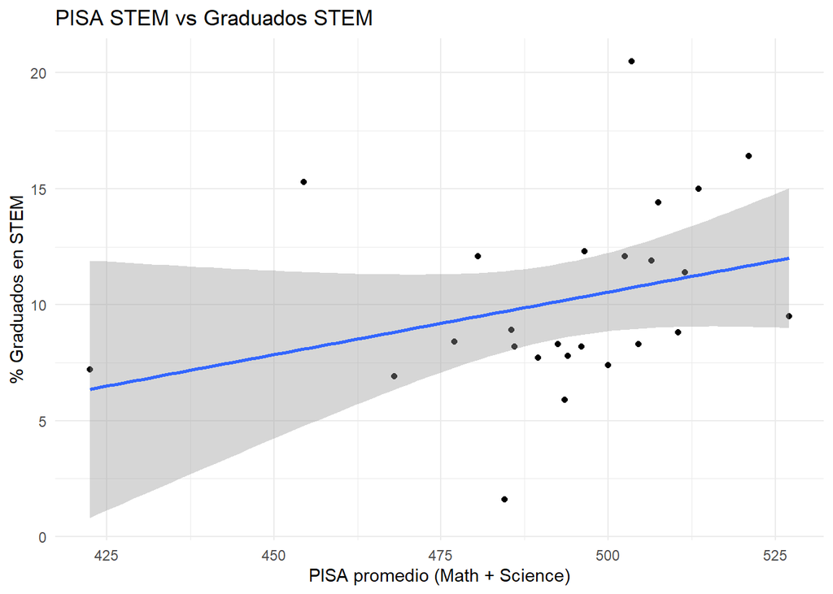

```r
ggplot(df, aes(x = PISA_STEM, y = STEM_grad)) +
  geom_point() +
  geom_smooth(method = "lm") +
  theme_minimal() +
  labs(title = "PISA STEM vs Graduados STEM", x = "PISA promedio (Math + Science)", y = "% Graduados en STEM")
```

```r
cor.test(df$PISA_STEM, df$STEM_grad, method = 'spearman')
```

```
##
##  Spearman's rank correlation rho
##
## data:  df$PISA_STEM and df$STEM_grad
## S = 1375.3, p-value = 0.01747
## alternative hypothesis: true rho is not equal to 0
## sample estimates:
##       rho
## 0.4710411
```

```r
modelo <- lm(STEM_grad ~ PISA_STEM, data = df)
summary(modelo)
```

```
##
## Call:
## lm(formula = STEM_grad ~ PISA_STEM, data = df)
##
## Residuals:
##     Min      1Q  Median      3Q     Max
## -8.1131 -2.3181 -0.9078  1.9384  9.7602
##
## Coefficients:
##              Estimate Std. Error t value Pr(>|t|)
## (Intercept) -16.46858   17.92703  -0.919    0.368
## PISA_STEM     0.05404    0.03632   1.488    0.150
##
## Residual standard error: 3.892 on 23 degrees of freedom
## Multiple R-squared:  0.0878, Adjusted R-squared:  0.04814
## F-statistic: 2.214 on 1 and 23 DF,  p-value: 0.1504
```

1. Gráfico de dispersión ocn regresión lineal

Se observa una ligera tendencia positiva: a mayor puntuación media en PISA (math+science), mayor % de graduados en STEM. La línea azul representa el modelo de regeresión lineal, con su banda de confianza en gris, lo que indica incertidumbre en la predicción. Sin embargo, los puntos están bastante dispersos, lo que sugiere una relación débil.

Aunque el modelo de regresión lineal no presenta una relación especialmente fuerte, se ha decidido aplicar un modelo de Análisis Discriminante Lineal (LDA) para explorar si, a pesar de ello, las puntuaciones PISA permiten clasificar a los países según su nivel de graduación en carreras STEM. Este enfoque busca complementar el análisis con una perspectiva predictiva basada en categorías.

- Análisis Discriminante

Se creó una variable para clasificar los países en ‘Alta’ o ‘Baja’ según si están por encima o por debajo de la mediana en % de graduados

```r
df <- df %>%
  mutate(clase_STEM = ifelse(STEM_grad >= median(STEM_grad), "Alta", "Baja")) %>%
  mutate(clase_STEM = factor(clase_STEM))
table(df$clase_STEM)
```

```
##
## Alta Baja
##   13   12
```

Ajusta un modelo LDA para predecir si un país tiene muchos o pocos graduados en carreras STEM, solo usando su puntuacion media en PISA (ciencias+matemáticas).

```r
lda_model <- lda(clase_STEM ~ PISA_STEM, data = df)
lda_model
```

```
## Call:
## lda(clase_STEM ~ PISA_STEM, data = df)
##
## Prior probabilities of groups:
## Alta Baja
## 0.52 0.48
##
## Group means:
##      PISA_STEM
## Alta  501.5769
## Baja  484.0000
##
## Coefficients of linear discriminants:
##                  LD1
## PISA_STEM 0.04905744
```

Los paises que tienen muchos graduados en STEM sacaron, de media, 501 puntos en PISA. Mientras que, los países que tienen pocos graduados en STEM sacaron 484 puntos de media. Por tanto, los países con mejor rendimiento académico en PISA tienden a tener más graduados en carreras STEM. El PISA_STEM: 0.049 es el “peso” que el modelo le da a la puntuación PISA para separar los países entre “Alta” y “Baja”.

Como el valor es positiva, significa que cuanto más alta sea la puntuacion PISA, más probable es que el país pertenezca al grupo “Alta”. Si fuera negativo, sería al revés

Genera las predicciones del modelo y crea una tabla de comparación entre lo real y lo predicho.

```r
lda_pred <- predict(lda_model)
df$lda_class <- lda_pred$class
table(Real = df$clase_STEM, Predicha = df$lda_class)
```

```
##       Predicha
## Real   Alta Baja
##   Alta   10    3
##   Baja    6    6
```

- 10 países fueron correctamente clasificados como Alta
- 6 países fueron correctamente clasificados como Baja
- 3 Países fueron clasificados como Baja cuando en realidad eran Alta
- 6 países fueron mal clasificados como Alta cuando en realidad eran Baja

Conclusiones

EL modelo acertó 16 de 25 casos, lo que representa una precisión del 64%. El modelo clasifica mejor los países del grupo “Alta” que los del grupo “Baja”. Aunque el modelo no es altamente preciso, sí que refueza la idea de una cierta sociación entre el rendimiento académico y la elección posterior de estudios universitarios

Finalmente, se represento gráficamente el primer eje discriminante, que resume la separación entre los dos grupos.

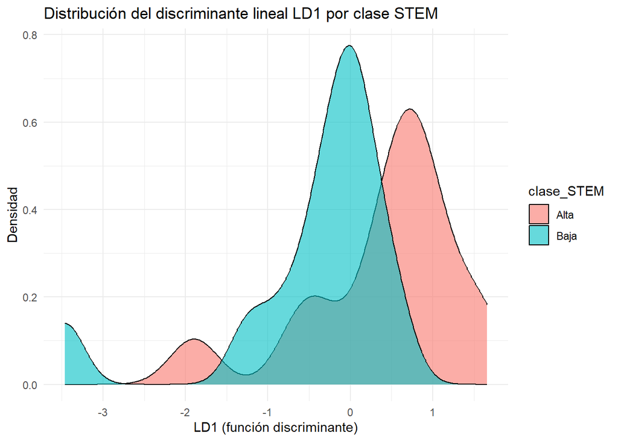

```r
df$LD1 <- lda_pred$x[,1]

ggplot(df, aes(x = LD1, fill = clase_STEM)) +
  geom_density(alpha = 0.6) +
  labs(title = "Distribución del discriminante lineal LD1 por clase STEM",
       x = "LD1 (función discriminante)", y = "Densidad") +
  theme_minimal()
```

El gráfico muestre que el modelo LDA logra separar parcialmente los países según su proporción de graduados en STEM usando solo su puntuación PISA. Aunque hay solapamientos entre los grupos se observa que los países ocn mejores resultados académicos tienden a posicionarse en la zona de valores más altos de LD1, lo que refuerza la idea de que el rendimiento en STEM puede estar relacionado con la elección de estudios en esas areás.

# 5. Reflexión final

El desarrollo del objetivo me ha llevado a:

- Evaluar la normalidad de los datos y seleccionar la técnica de correlación adecuada
- Interpretar un modelo de regresión y valorar su significar
- Construir e interpretar un modelo LDA.